# act_report

*Hi everyone, i am most excited to share with you the insights and visualizations produced from my wrangled data. I mean, its beautiful turning raw data from nothing to something one could actually present. Well, without further ado let me get to the presentation*

*A quick background of my wrangled data: This data was provided by [Udacity](https://udacity.com/) for my second project in the Data Analytics Nanodegree Program i am currently enrrolled in. I have wrangled my data and i outline the steps to do that here. I have highlighted below the insights gotten from the analysis of this wrangled data. Also, i made amazing visualizations to better communicate my findings from the data.*

## Exploratory Data Analysis

*`.describe()`, `.isnull()` e.t.c among many other methods used in pandas to perform exploratory data analysis was also applied to the wrangled data. I was able to get statistical facts about my data. Some of these facts include:*

- the average rating for each dog is 10.8
- The maximum retweet count for a tweet_id is a wholesome 70839 while the maximum favourite count for a dog tweet id is about 145k
- the average confidence level of prediction algorithm 1 is the highest of all prediction algorithms with 0.60

This is an image of the `.describe()` method in action

[figure not shown]

## Data Visualizations

*Visualizations are best used to effectively communicate answers to questions posed for data analysis. I posed two questions and attempted to communicate the answer vissually. Now check these question out;*

### Is there a correlation between the favorite count and retweet count?

`df_master.corr(method = 'pearson')`

The above code in action:

[figure not shown]

- the snapshot would have done a good job in answering the question but how about this?

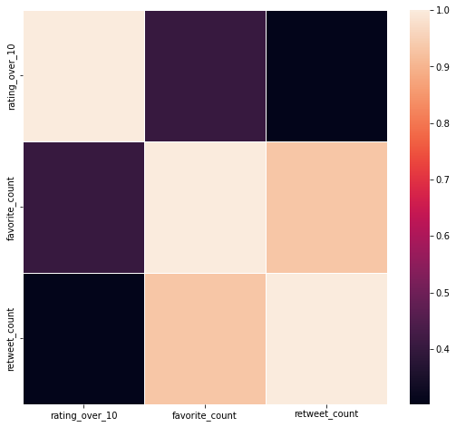

*You see that?the colours did an amazing job passing the information accross!*

*Now lets check out the other question posed*

## Comparing the performance of algorithm's predictions(p1,p2 and p3). How did each fair?

*Given that the image of each dog was ran through a neural network to predict if the image is a dog or not and also to return the confidence of each prediction and its percieved breed*

*here, i analysed and compare the three predictions and how they differ. Firstly, i defined a function to plot dog breeds where the number of dog breeds predicted has more than 20 occurences for each predition ,that is, where the prediction is truly a dog*

*below are the results of this analysis, where i was able to know how each prediction faired*

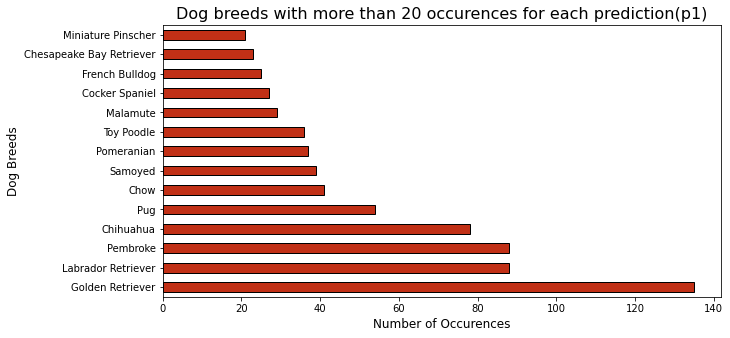

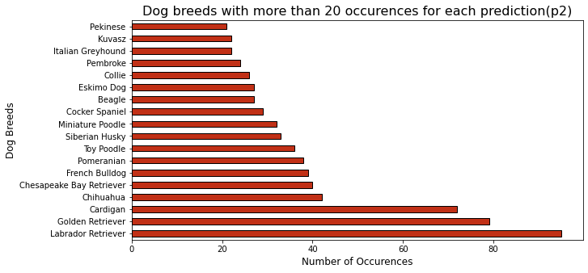

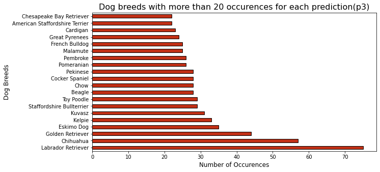

*You will quickly notice the difference in the number of dog breeds in each visuals*. *Now, thats how the prediction faired. The 3rd predictions have lower level of confidence compared to the first and second one*

*i also wrote a code to detect some information about the breeds present in the visualizations above* check them out👇👇

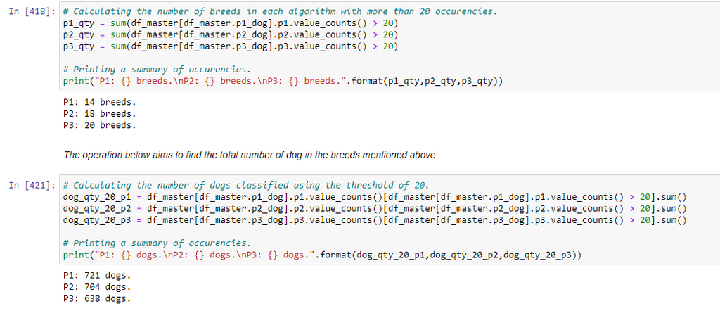

*Yeah, so i hope y'all get the gist. visualizations are amazing and can go a long way to tell the data's story. Peace!!*